# Handout W05 — Korelacja, regresja i raport ilościowy

Zarządzanie informacją — mapa pojęć i sprawdziany rozumienia — 2026/27

Marek Deja

2026/27

# Pytanie, estymanda i wynik

W S02 x oznacza deklarowaną użyteczność katalogu, a y — obserwowany czas. Indeks opisuje deklarowaną użyteczność katalogu. Ujemny związek oznacza współwystępowanie wyższej oceny z krótszym czasem; czas porzuconego zadania raport czyta obok powodzenia.

Jednostką jest osoba z kompletną parą. Pytania o korelację, średnią przewidywaną i zgodność pomiarów mają trzy różne odpowiedzi. Przed obliczeniem ustala się konstrukt, skalę, populację i regułę braków.

Pytania o związek dwóch zmiennych

| Pytanie | Estymanda | Wynik z próby |
| --- | --- | --- |
| Jak silna jest liniowa współzmienność? | $\rho_P$ | r Pearsona |
| Jak zgodna jest kolejność? | $\rho_S$ | $r_S$ Spearmana |
| O ile różni się średni y na jednostkę x? | $\beta_1$ | nachylenie $b_1$ |
| Czy samoocena trafnie podaje poziom? | Średni błąd w porównywalnej skali | Średni błąd samooceny i granice zgodności |

# Wzory czytane zdaniem

$$r=\frac{\sum(x_i-\bar x)(y_i-\bar y)}
{\sqrt{\sum(x_i-\bar x)^2\sum(y_i-\bar y)^2}},\qquad
t=r\sqrt{\frac{n-2}{1-r^2}},\quad df=n-2.$$

Licznik łączy odchylenia obu zmiennych od ich średnich, a mianownik standaryzuje wynik: r jest liczbą bez jednostki z zakresu [−1; 1] i opisuje związek liniowy. Zależność w kształcie U daje r = 0. Spearman jest korelacją rang, przy remisach — średnich rang. Klasyczny test zerowej korelacji Pearsona zakłada niezależne pary z rozkładu normalnego dwóch zmiennych; wynik Spearmana raportuje się statystyką S i p podanymi przez program.

# Dwa losowania, dwa pytania

Permutacja przestawia y względem x: rozkłady zostają, parowanie zmienia się przy hipotezie niezależności i wymienialności. W Monte Carlo dwustronne p ma postać $(1+\#\{|r^*_b|\geq|r|\})/(B+1)$; w pełnym wyliczeniu liczbę skrajnych układów dzieli się przez liczbę wszystkich układów.

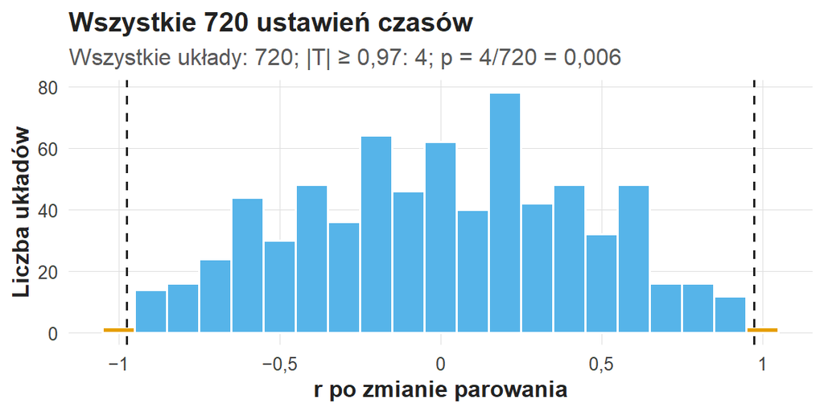

Wszystkie 720 ustawień czasów sześciu par. Histogram r po zmianie parowania, od −0,974 do 0,974; linie przerywane przy ±0,974; cztery układy leżą na liniach, więc p = 4/720 = 0,0056.

Bootstrap losuje całe pary z powtórzeniami i zachowuje relację wewnątrz osoby, aby przybliżyć niepewność współczynnika. Raport podaje metodę przedziału i liczbę replik z obliczonym współczynnikiem. Powtarzane pomiary i klastry wymagają przestawień w obrębie bloków; test permutacyjny sprawdza niezależność par, a test t — zerową korelację liniową.

# Czytamy model

$$E(Y\mid X=x)=\beta_0+\beta_1x,\qquad
\widehat y=b_0+b_1x,\qquad e_i=y_i-\widehat y_i,\qquad
R^2=1-\frac{\sum e_i^2}{\sum(y_i-\bar y)^2}.$$

$b_1$ ma jednostkę y na jednostkę x, tutaj minuty na punkt; $b_0$ dotyczy x = 0, poza skalą 1–5. Reszta to różnica wyniku zaobserwowanego i przewidywanego. $R^2$ to część sumy kwadratów odchyleń y od średniej przypadająca na prostą; w regresji prostej $R^2=r^2$.

# Mały przykład wykładowy

Sześć par: x = (1, 2, 2, 3, 4, 5), y = (15, 12, 14, 10, 9, 6) — celowo regularne dane dydaktyczne; zbiór S02 w ćwiczeniu C08 ma 141 par i r = −0,126. Pearson: r = −0,974; t(4) = −8,668; p = 0,0010; wszystkie 720 ustawień dają 4 układy co najmniej tak skrajne, p = 0,0056. Model: $\widehat y=17{,}28-2{,}215x$, 95% CI nachylenia [−2,93; −1,51]; nachylenie porównuje osoby o różnych ocenach.

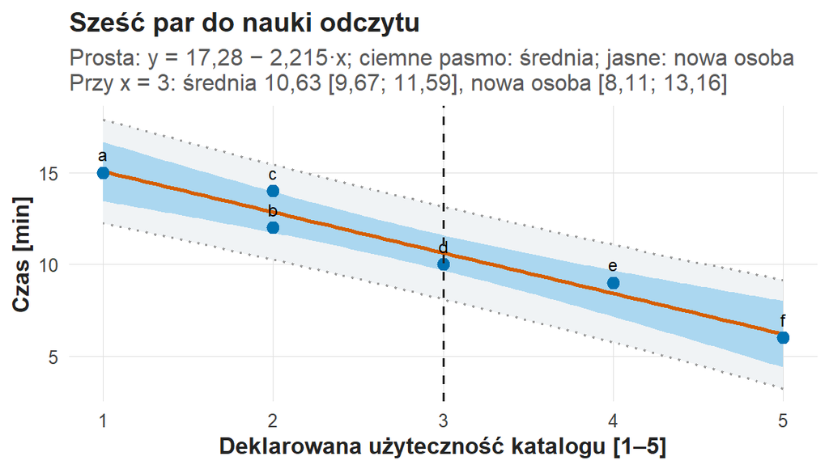

Sześć par z prostą regresji. Oś pozioma: deklarowana użyteczność 1–5; oś pionowa: czas w minutach. Punkty a–f leżą wzdłuż prostej od 15 do 6 minut. Przy x = 3 prognoza 10,63 minuty; ciemne pasmo (średnia warunkowa) obejmuje 9,67–11,59, jasne (nowa osoba) 8,11–13,16 minuty.

Szerszy przedział predykcji zawiera zmienność indywidualną. Prognoza obejmuje zakres obserwowanych x, od 1 do 5.

# Co sprawdzamy na wykresie

Krzywiznę, rozrzut zależny od poziomu, skupienia, nietypowe punkty i zakres. Dźwignia dotyczy nietypowego x, reszta — odchylenia y od prostej, a odległość Cooka — wpływu punktu na dopasowanie; w sześciu parach największą dźwignię ma osoba f (0,600). Decyzja o punkcie nietypowym opiera się na sprawdzeniu rekordu. Klasyczne przedziały regresji zakładają poprawną średnią, niezależność i stałą wariancję błędów, a wnioskowanie t w małej próbie — normalność błędów.

# Kalibracja: zgodność poziomów

Pięć osób przewiduje własny wynik testu i rozwiązuje test. Każda samoocena przewyższa wynik o 20 punktów procentowych, a korelacja wynosi 1: korelacja opisuje zgodność kolejności, a kalibracja — zgodność poziomów.

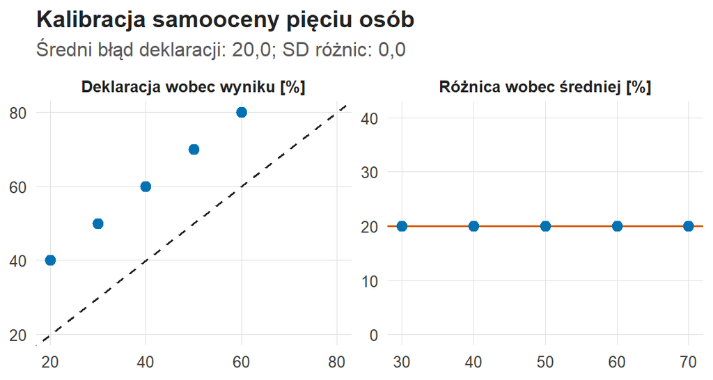

Kalibracja samooceny pięciu osób. Lewy panel: samoocena wobec wyniku; punkty leżą 20 punktów procentowych nad linią zgodności y = x. Prawy panel: różnica samoocena minus wynik wobec średniej obu pomiarów; wszystkie różnice wynoszą 20.

# Trzy zdania do poprawienia

„r = −0,30 to spadek kompetencji o 30%” → „Deklarowana użyteczność katalogu i czas korelują na poziomie −0,30; korelacja opisuje siłę związku na skali od −1 do 1”.

„r = 1 dowodzi trafnej samooceny” → „Samooceny zachowują kolejność wyników i zawyżają każdy wynik o 20 punktów procentowych”.

„Przedział obejmuje zero, więc związek nie istnieje” → „Przedział obejmuje zero i wartości umiarkowanie ujemne, więc dane są zgodne z brakiem związku liniowego i ze związkiem umiarkowanym; wzorzec nieliniowy wymaga wykresu”.

# Akapit wyniku

Akapit podaje N kompletnych par, miarę, przedział z metodą, test i p, p permutacyjne i B. Dla regresji dodaje nachylenie z jednostką i przedziałem, $R^2$ oraz ograniczenie diagnostyczne. Następnie odpowiada na pytanie merytoryczne czasownikiem zgodnym z projektem.

Generatywna SI podlega tym samym regułom odczytu: sprawdzamy nazwę konstruktu, liczby, N, metodę przedziału i czasownik. Zdanie „p = 0,08 oznacza 8% szans braku efektu” poprawiamy na „przy prawdziwej $H_0$ wynik co najmniej tak skrajny zdarzałby się w 8% prób”. Interpretację student pisze samodzielnie.

# Mapa rozwinięć

Galeria rozszerzeń i warunki odczytu

| Obraz lub model | Odczyt | Warunek odczytu |
| --- | --- | --- |
| $a+b\,e^{-cx}$ | Zmienne tempo spadku średniego czasu | Asymptota jest parametrem modelu |
| Wiolina | Gęstość i kształt rozkładu | N z etykiety grupy |
| Pareto | Uporządkowane częstości i kumulacja | Priorytet łączy częstość z powagą problemu |
| Koło | Rozłączny podział jednej całości | Kategorie rozłączne i wyczerpujące |
| Mapa cieplna | Odsetek na wspólnej skali koloru | Mianownik w każdej komórce |
| Wydajność | Opóźnienie i przepustowość przy obciążeniu | Czas serwera i czas osoby mierzone osobno |
| Reszty cząstkowe | $e_i+b_1x_i$ względem x | Składnik modelu przy uwzględnionych zmiennych |

Kontekst: Hargittai (2002), Internet Skills Scale, DigComp 2.2 i ACRL; pełne odnośniki zawiera wykład. Ćwiczenie C08 rozwija odczyt wyników, C09 planuje argument, a C10 sprawdza raport i jego odtwarzalność.